# Stan tutorial Empirical Models

Nicolas Padilla

January 23, 2018

# Stan tutorial for Empirical Models

Stan (http://mc-stan.org/) is probabilistic modeling language with highly-efficient Bayesian computation, this is, it allows you to write models similarly as you would write them using mathematical notation, without coding the estimation procedure.

It allows users to estimate their models using two procedures:

- Hamiltonian Monte Carlo sampling - No U-Turn Sampling (NUTS)
- Variational Inference - Automatic Differenciation Variational Inference (ADVI)

(It also has other features: e.g. MAP estimation)

You can use it from:

- R (RStan)
- python (PyStan)
- and more …

Installation instructions for RStan (https://github.com/stan-dev/rstan/wiki/RStan-Getting-Started)

## Load packages

First, we load the package and set the *auto_write* option to avoid recompiling code

```r
library(rstan)
```

```r
library(ggplot2)
library(shinystan)
rstan_options(auto_write = TRUE)
```

# Main setting

Consider data $Y$, and parameters of a model $\theta$.

A model is defined in terms of the joint distribution of $Y$ and $\theta$,this is $p(Y,\theta)$.

In general, we describe the joint distribution using two components:
$$p(Y,\theta)=p(Y|\theta)\cdot p(\theta)$$

- $p(Y|\theta)$: likelihood
- $p(\theta)$: prior

The **likelihood** is what is traditionally considered the model in frequentist statistics. It describes how the data is generated from the parameters.

The **prior** indicates our beliefs (before looking at the data) of what the value of this parameter may be. It may seem that the choice of a prior distribution may affect our analysis, but in practice its impact is minor if there is enough information in the data and the prior is set *uninformatively*.

We are interested in obtaining $p(\theta|Y)$, the posterior distribution of $\theta$ given that we observe the data $Y$. This is, we want to update our beliefs of what is the value of the parameter of the model, given that we have observed data.

Using Bayes’ rule this can be written as:
$$p(\theta|Y)=\frac{p(Y|\theta)\cdot p(\theta)}{p(Y)}$$

In practice, $p(Y)$ the marginal distribution of $Y$, or marginal likelihood, is hard to compute (involves integrating out $\theta$). Luckily, the posterior distribution, is a distribution over $\theta$, so for that purpuse $p(Y)$ only works as a normalizing constant that makes this distribution integrates to 1. So we can say that the posterior distribution is proportional to the product of the likelihood and the prior.
$$p(\theta|Y)\propto p(Y|\theta)\cdot p(\theta)$$

Because in most (interesting) cases we cannot analytically find the posterior distribution, **our goal** is to draw a sample of this distribution. Stan allows to obtain such sample, using NUTS (a specific type of Hamiltonian Monte Carlo algorithm) without coding anything else than the prior and the likelihood.

# Linear regression

Consider the most simple linear regression (one covariate)
$$Y_i = \alpha+X_i\beta+\varepsilon_i, \ \ \ \varepsilon_i\sim N(0,\sigma^2), \ \ \forall i=1,\ldots, N$$
## Simulate data

We simulate data with $N=200$ observations

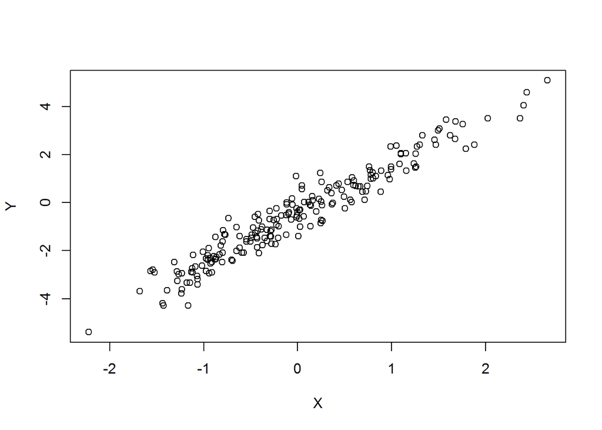

```r
set.seed(0)
N=200
X=rnorm(N)
alpha=-0.5
beta=2
sigma=0.5
Y=alpha+beta*X+rnorm(N,sd=sigma)
plot(X,Y)
```

## Writting a model in Stan

A model code in Stan has the following components:

- `functions` (optional)
- `data`
- `transformed data` (optional)
- `parameters`
- `transformed parameters` (optional)
- `model`
- `generated quantities` (optional)

```
functions {
// ... function declarations and definitions ...
}
data {
// ... declarations ...
}
transformed data {
// ... declarations ... statements ...
}
parameters {
// ... declarations ...
}
transformed parameters {
// ... declarations ... statements ...
}
model {
// ... declarations ... statements ...
}
generated quantities {
// ... declarations ... statements ...
}
```

### Linear regression as a probabilistic model

In our notation we identify $Y$ as data and $\theta=(\alpha,\beta,\sigma)$ as the parameters of the model.

First, we need to define the likelihood. We could write the linear regression using our likelihood notation $p(Y|\theta)$.
$$Y_i|\alpha,\beta,\sigma\sim \mathcal{N}\left(\alpha+X_i\beta,\sigma^2\right), \ \ \forall i=1,\ldots, N$$

Second, we need to define a prior distribution for those parameters. For this we will choose:

$$\alpha\sim \mathcal{N}\left(0,5\right)$$
$$\beta\sim \mathcal{N}\left(0,5\right)$$

The beauty of Stan is that we are not forced to use conjugate priors (e.g. Gamma or Inv.Gamma distribution for $\sigma$). In this case we can set an unbounded distribution on a bounded parameter. Stan automatically would transform this to a proper truncated distribution. In this case we use Cauchy, which is similar to a Gaussian, but allowing for outliers (heavy tail).

$$\sigma\sim\text{Truncated_Cauchy}(0,5,lower=0)\cdot$$

- **Dimensionality**: The prior depends on whether the parameter is a real value, a vector or a matrix (or arrays of those).
- **Support**: Some parameters have support only in specific regions. In our example $\sigma$ has to be positive.
- **Special cases**: Some parameters have specific structures, and require specific priors. For example, a covariance matrix, or probabilities over a multinomial outcome (a vector of positive values that sum to 1).

If you are not familiar with the model, you could: - See what previous papers have done for similar models - Go for the Stan manual, they have different suggestions for priors for different type of models - Use priors of simpler models for components of your model.

```stan
data {
  int N;                 // number of observations
  vector[N] x;           // covariate
  vector[N] y;           // dependent variable
}
parameters {
  real alpha;            // intercept
  real beta;             // coefficients
  real<lower=0> sigma;   // std dev of error
}
model {
  alpha ~ normal(0, 5);
  beta ~ normal(0, 5);
  sigma ~ cauchy(0, 5);
  y ~ normal(rep_vector(alpha,N)+beta*x,sigma);
}
```

There are several others you can find in the documentation.

When estimating a model, there are two things `stan` does: 1. `stan` compiles your Stan code into C++ code, that can be then estimated. 2. `stan` draw samples of the parameters from the posterior distribution defined in the model.

```r
data_list<-list(N=N,x=X,y=Y)
fit<-stan(file = "lin_reg.stan",data = data_list,chains = 1,iter = 1000)
#fit<-stan(model_code = lin_reg_st,data = data_list,chains = 1,iter = 1000)
print(fit)
traceplot(fit,pars=c("alpha","beta","sigma"))
```

```r
data_list<-list(N=N,x=X,y=Y)
fit<-sampling(lin_reg,data = data_list,chains = 1,iter = 1000)
```

```
##
##
## Gradient evaluation took 0 seconds
## 1000 transitions using 10 leapfrog steps per transition would take 0 seconds.
## Adjust your expectations accordingly!
##
##
## Iteration:   1 / 1000 [  0%]  (Warmup)
## Iteration: 100 / 1000 [ 10%]  (Warmup)
## Iteration: 200 / 1000 [ 20%]  (Warmup)
## Iteration: 300 / 1000 [ 30%]  (Warmup)
## Iteration: 400 / 1000 [ 40%]  (Warmup)
## Iteration: 500 / 1000 [ 50%]  (Warmup)
## Iteration: 501 / 1000 [ 50%]  (Sampling)
## Iteration: 600 / 1000 [ 60%]  (Sampling)
## Iteration: 700 / 1000 [ 70%]  (Sampling)
## Iteration: 800 / 1000 [ 80%]  (Sampling)
## Iteration: 900 / 1000 [ 90%]  (Sampling)
## Iteration: 1000 / 1000 [100%]  (Sampling)
##
##  Elapsed Time: 0.05 seconds (Warm-up)
##                0.028 seconds (Sampling)
##                0.078 seconds (Total)
```

```r
#fit<-stan(model_code = lin_reg,data = data_list,chains = 1,iter = 1000)
print(fit)
```

```
## Inference for Stan model: e747cf17fbff13d5a65201ae7f38fb02.
## 1 chains, each with iter=1000; warmup=500; thin=1;
## post-warmup draws per chain=500, total post-warmup draws=500.
##
##        mean se_mean   sd  2.5%   25%   50%   75% 97.5% n_eff Rhat
## alpha -0.48    0.00 0.03 -0.55 -0.50 -0.48 -0.46 -0.42   477 1.00
## beta   2.01    0.00 0.04  1.93  1.98  2.00  2.03  2.08   500 1.00
## sigma  0.50    0.00 0.03  0.46  0.49  0.50  0.52  0.56   340 1.00
## lp__  37.25    0.08 1.20 34.32 36.67 37.53 38.14 38.62   226 1.01
##
## Samples were drawn using NUTS(diag_e) at Tue Feb 06 18:38:05 2018.
## For each parameter, n_eff is a crude measure of effective sample size,
## and Rhat is the potential scale reduction factor on split chains (at
## convergence, Rhat=1).
```

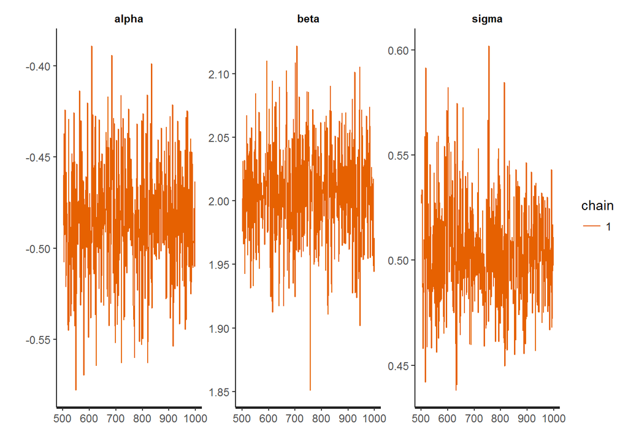

```r
traceplot(fit,pars=c("alpha","beta","sigma"))
```

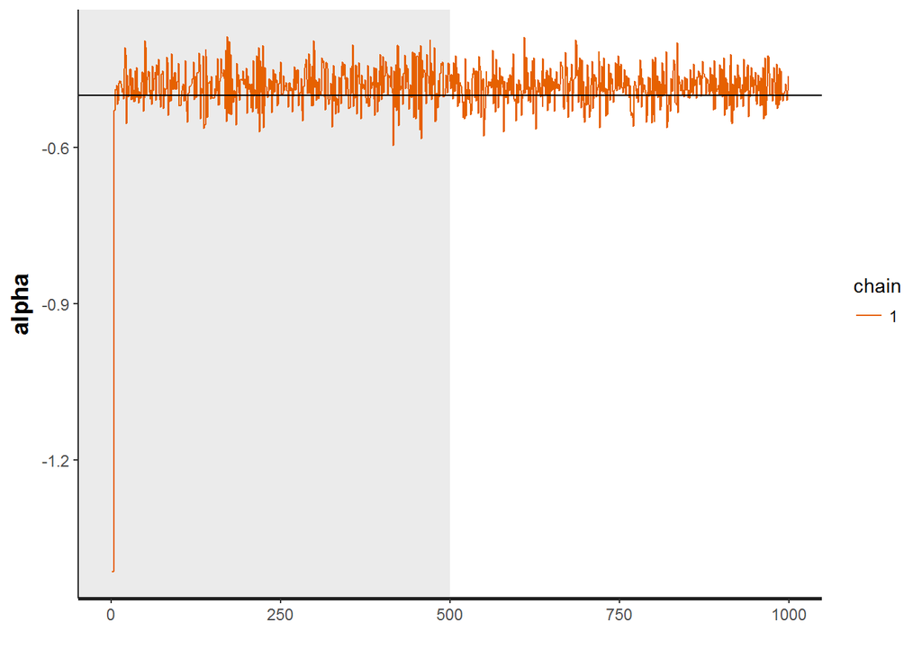

```r
traceplot(fit,pars="alpha",inc_warmup=TRUE)+geom_hline(yintercept = alpha,colour="black")
```

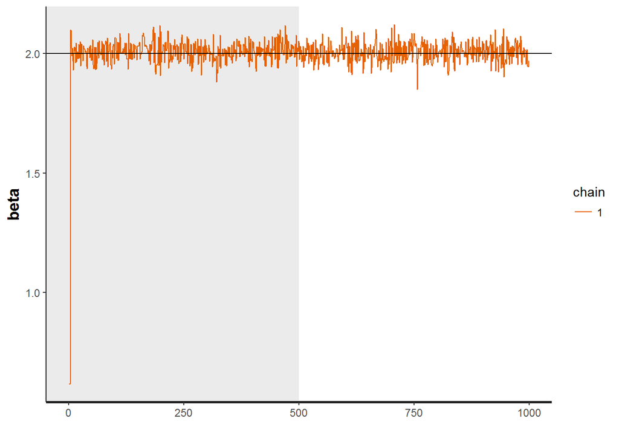

```r
traceplot(fit,pars="beta",inc_warmup=TRUE)+geom_hline(yintercept = beta,colour="black")
```

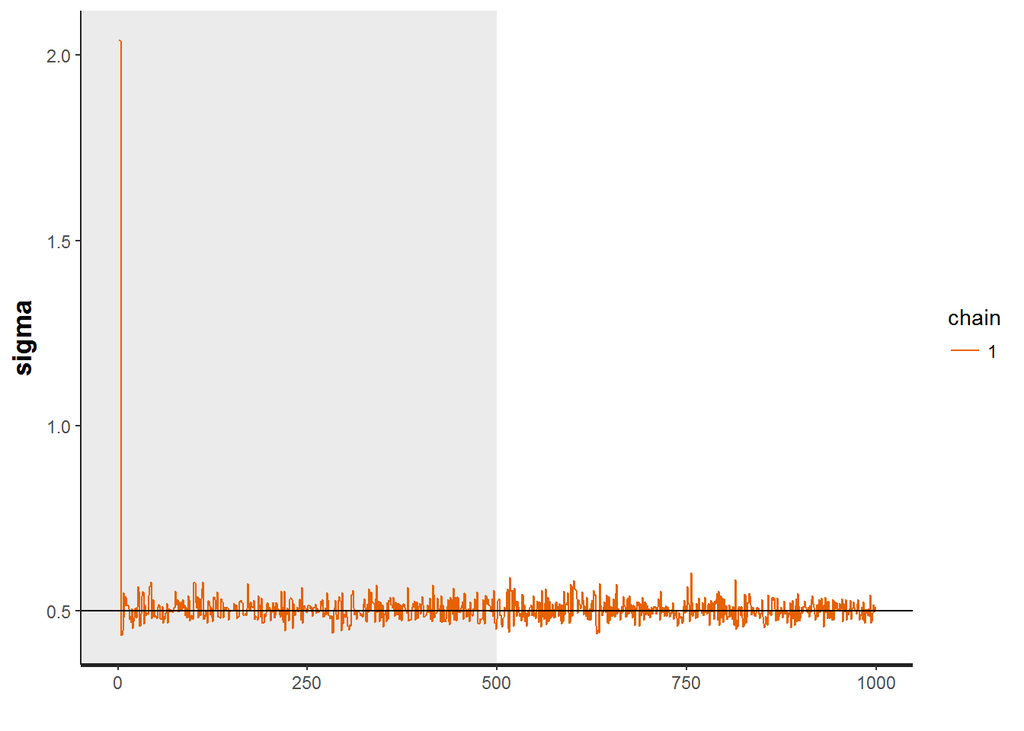

```r
traceplot(fit,pars="sigma",inc_warmup=TRUE)+geom_hline(yintercept = sigma,colour="black")
```

# Logistic regression

Now we will estimate a logistic regression for a binary outcome $Y_i\in\lbrace 0,1\rbrace$ regressed on a vector of covariates instead of a single covariate.

Let say that $Y$ is whether a customer bought a product a particular month, and we intent to measure the effect of 2 covariates on purchase probability, price and Feature (plus intercept).

$$X_i=\begin{bmatrix}1&,&Price_i&,& Feature_i \end{bmatrix}'$$

Now I’m including the intercept as part of beta (by setting the first variable in $X_i$ to 1, for all observations).

The logistic regression is described by:
$$\text{logit} \left(p(Y_i=1|\beta,X_i)\right) = X_i'\cdot\beta$$

where $\text{logit}(p)=\log\left(\frac{p}{1-p}\right)$

With some algebra we can explicitly write $p(Y_i=1|\beta,X_i)$ by

$$p(Y_i=1|\beta,X_i)=\text{logit}^{-1}\left(X_i'\cdot\beta\right)=\frac{1}{1+\exp(-X_i'\cdot\beta)}=\frac{\exp(X_i'\cdot\beta)}{1+\exp(X_i'\cdot\beta)}$$
In summary:

$$Y_i|\beta,X_i\sim Bernoulli\left(\text{logit}^{-1}\left(X_i'\cdot\beta\right)\right)$$

With respect to the prior for $\beta$ we use again Gaussian priors:

$$\beta_k\sim \mathcal{N}\left(0,5\right)$$

Now with this the stan model can be written as:

```stan
data {
  int<lower=0> N;
  int<lower=1> P;
  matrix[N,P] x;
  int<lower=0,upper=1> y[N];
}
parameters {
  vector[P] beta;
}
model {
  beta ~ normal(0,5);
  y ~ bernoulli_logit(x*beta);
  //y ~ bernoulli(inv_logit(x*beta));
}
```

Again, we simulate data with an intercept and two covariates

```r
library(boot) # inverse logit function
set.seed(0)
N=1500
P=3
X=cbind(rep(1,N),
        rnorm(N),
        rbinom(n = 1,size = 1,prob = 0.5))
beta=c(0.5,-1,1)
u = runif(N)
Y=(u<=inv.logit(c(X%*%beta)))*1
```

Now, finally we estimate the model

```r
data_list<-list(N=N,P=P,x=X,y=Y)
logrfit<-sampling(log_reg,data = data_list,chains = 3,iter = 1000)
```

```
##
##
## Gradient evaluation took 0 seconds
## 1000 transitions using 10 leapfrog steps per transition would take 0 seconds.
## Adjust your expectations accordingly!
##
##
## Iteration:   1 / 1000 [  0%]  (Warmup)
## Iteration: 100 / 1000 [ 10%]  (Warmup)
## Iteration: 200 / 1000 [ 20%]  (Warmup)
## Iteration: 300 / 1000 [ 30%]  (Warmup)
## Iteration: 400 / 1000 [ 40%]  (Warmup)
## Iteration: 500 / 1000 [ 50%]  (Warmup)
## Iteration: 501 / 1000 [ 50%]  (Sampling)
## Iteration: 600 / 1000 [ 60%]  (Sampling)
## Iteration: 700 / 1000 [ 70%]  (Sampling)
## Iteration: 800 / 1000 [ 80%]  (Sampling)
## Iteration: 900 / 1000 [ 90%]  (Sampling)
## Iteration: 1000 / 1000 [100%]  (Sampling)
##
##  Elapsed Time: 15.694 seconds (Warm-up)
##                14.744 seconds (Sampling)
##                30.438 seconds (Total)
##
##
##
## Gradient evaluation took 0 seconds
## 1000 transitions using 10 leapfrog steps per transition would take 0 seconds.
## Adjust your expectations accordingly!
##
##
## Iteration:   1 / 1000 [  0%]  (Warmup)
## Iteration: 100 / 1000 [ 10%]  (Warmup)
## Iteration: 200 / 1000 [ 20%]  (Warmup)
## Iteration: 300 / 1000 [ 30%]  (Warmup)
## Iteration: 400 / 1000 [ 40%]  (Warmup)
## Iteration: 500 / 1000 [ 50%]  (Warmup)
## Iteration: 501 / 1000 [ 50%]  (Sampling)
## Iteration: 600 / 1000 [ 60%]  (Sampling)
## Iteration: 700 / 1000 [ 70%]  (Sampling)
```

[output cut: 16 more lines]

```
## Iteration: 100 / 1000 [ 10%]  (Warmup)
## Iteration: 200 / 1000 [ 20%]  (Warmup)
## Iteration: 300 / 1000 [ 30%]  (Warmup)
## Iteration: 400 / 1000 [ 40%]  (Warmup)
## Iteration: 500 / 1000 [ 50%]  (Warmup)
## Iteration: 501 / 1000 [ 50%]  (Sampling)
## Iteration: 600 / 1000 [ 60%]  (Sampling)
## Iteration: 700 / 1000 [ 70%]  (Sampling)
## Iteration: 800 / 1000 [ 80%]  (Sampling)
## Iteration: 900 / 1000 [ 90%]  (Sampling)
## Iteration: 1000 / 1000 [100%]  (Sampling)
##
##  Elapsed Time: 11.167 seconds (Warm-up)
##                13.507 seconds (Sampling)
##                24.674 seconds (Total)
```

```r
#fit<-stan(model_code = lin_reg,data = data_list,chains = 1,iter = 1000)
print(logrfit)
```

```
## Inference for Stan model: f47e052fb15dbc57c780357bc392a195.
## 3 chains, each with iter=1000; warmup=500; thin=1;
## post-warmup draws per chain=500, total post-warmup draws=1500.
##
##            mean se_mean   sd    2.5%     25%     50%     75%   97.5% n_eff
## beta[1]    0.73    0.18 3.42   -5.58   -1.68    0.48    3.04    7.92   380
## beta[2]   -0.91    0.00 0.07   -1.06   -0.96   -0.91   -0.86   -0.78   508
## beta[3]    0.70    0.18 3.42   -6.49   -1.61    0.94    3.10    7.04   380
## lp__    -707.99    0.05 1.15 -711.01 -708.46 -707.70 -707.16 -706.63   443
##         Rhat
## beta[1] 1.00
## beta[2] 1.01
## beta[3] 1.00
## lp__    1.01
##
## Samples were drawn using NUTS(diag_e) at Wed Feb 28 17:10:06 2018.
## For each parameter, n_eff is a crude measure of effective sample size,
## and Rhat is the potential scale reduction factor on split chains (at
## convergence, Rhat=1).
```

You can even rename the parameters by changing the ggplot2 object

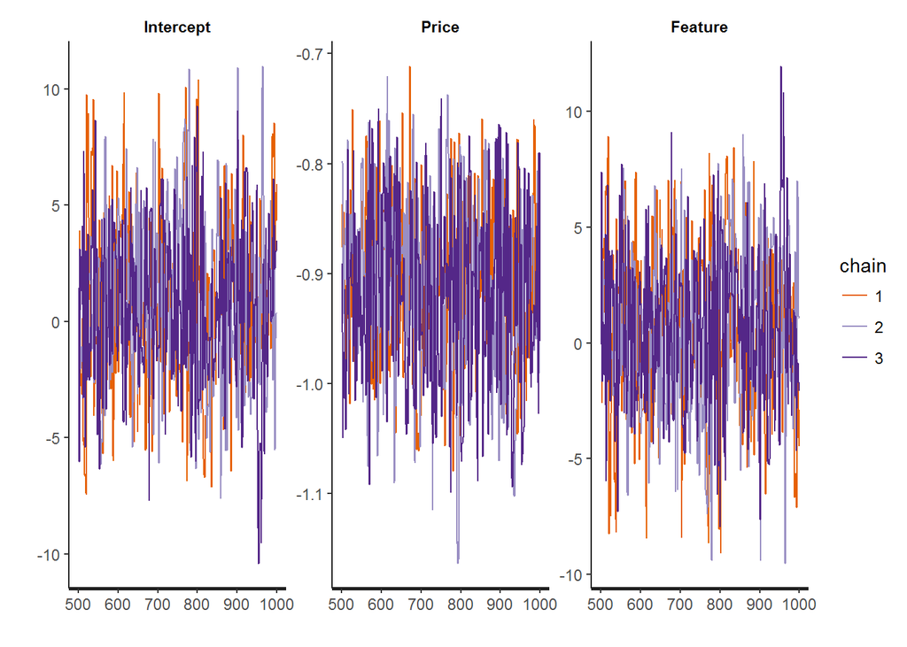

```r
trace <- traceplot(logrfit,pars="beta")
levels(trace$data$parameter) <- c("Intercept","Price","Feature")
plot(trace)
```

# Hierarchical model

$$Y_{it}|\alpha,\beta,\sigma\sim \mathcal{N}\left(X_{it}'\cdot\beta_i,\sigma^2\right), \ \ \forall i=1,\ldots, I,\;\forall i=1,\ldots, I,\;$$

Second, we need to define a prior distribution for those parameters. For this we will choose:

$$\beta_i|\mu_\beta,\Sigma_\beta\sim \mathcal{N}(\mu_\beta,\Sigma_\beta)$$
For the population priors we could model using standard conjugate priors (Normal, Wishart / Inverse Wishart).

However, the benefit of using Stan is that we do not need to set conjugate priors. Instead, we want priors that are flexible enough (uninformative), and computationally convenient.

For the mean use independent Gaussian:

$$\mu_\beta\sim \mathcal{N}(0,5\cdot \mathbb{I}_P)$$

And for the variance, we first decompose it into standard deviations and correlations, and we impose positive priors on standard deviations, and a particular prior built in in stan for correlation matrices.

$$\Sigma_\beta =\text{diag}(\tau)\cdot R\cdot \text{diag}(\tau)=\text{diag}(\tau)\cdot L_R L_R'\cdot \text{diag}(\tau)$$

where $\tau$ is a vector of the standard deviations of $\beta$, $R$ is the correlation matrix, and $L_R$ its cholesky decomposition.

We follow suggestions from the Stan manual. Notice that all values relies in continuous variables being standardized (both covariates and outcomes).

$$\tan^{-1} \left(\frac{\tau}{2.5}\right) \sim U[0,\pi/2]$$

$$L_R \sim \text{LKJ_corr_cholesky}(2)$$

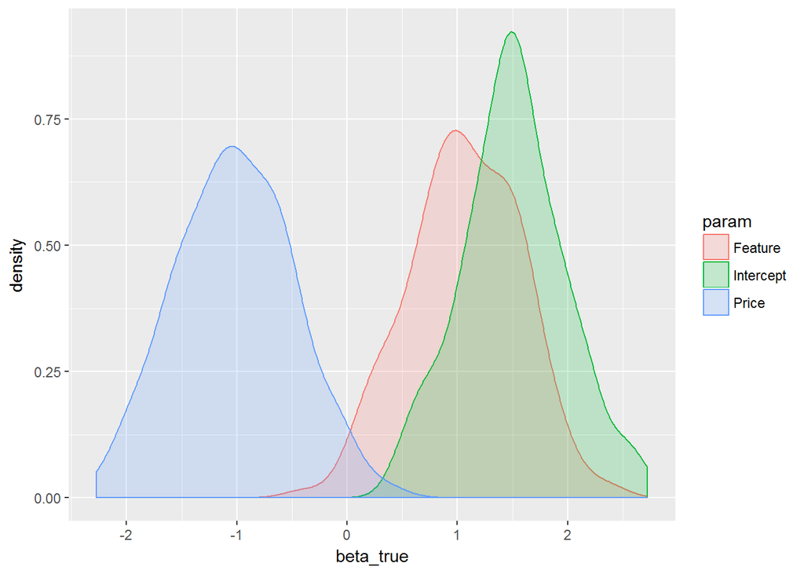

```r
library(MASS) # mvrnorm
set.seed(0)
I=200
T=40
P=3
N=I*T
X=cbind(rep(1,N),
        rnorm(N),
        rnorm(N))
mu_beta=c(1.5,-1,1)
sigma_beta = diag(rep(0.5^2,P))
beta = mvrnorm(n = I,mu = mu_beta,Sigma = sigma_beta)
ii <- rep(1:I, each = T)

sigma_y <-0.5
Y=rep(0,N)

for (n in 1:N) {
  Y[n] = rnorm(1,mean = beta[ii[n],]%*%X[n,],sd = sigma_y)
}
ggplot(data = data.frame(beta_true=c(beta),param=rep(c("Intercept","Price","Feature"),each = I)),
       aes(x=beta_true,colour=param,fill=param))+geom_density(alpha=0.2)
```

```stan
data {
  int<lower=0>                          N; // number of total observations
  int<lower=1>                          I; // number of individuals
  int<lower=1,upper=I>              ii[N]; // individual of each observation
  int<lower=1>                          P; // number of covariates
  matrix[N,P]                           x; // covariates
  real                               y[N]; // outcome
}
parameters {
  matrix[P,I]                            z; // individual standard normal
  row_vector[P]                    mu_beta; // mean vector
  vector<lower=0,upper=pi()/2>[P] tau_unif; // unif. population standard dev.
  cholesky_factor_corr[P]              L_R; // cholesky decomp. of correlation matrix
  real<lower=0>                    sigma_y; // variance of regression error term
}
transformed parameters{
  matrix[I,P]                        beta; // individual coefficients
  vector<lower=0>[P]                  tau; // population standard deviation
  for (k in 1:P)
    tau[k] = 2.5 * tan(tau_unif[k]);
  beta = rep_matrix(mu_beta,I) + (diag_pre_multiply(tau,L_R) * z)';
}
model {
  to_vector(z) ~ normal(0, 1);
  L_R ~ lkj_corr_cholesky(2);
  mu_beta ~ normal(0,5);
  sigma_y ~ cauchy(0,2);
  // tau_unif ~ uniform(0,pi()/2); this is not necessary
  y ~ normal(rows_dot_product(beta[ii] , x), sigma_y);
  //y[n] ~ normal(beta[ii[n]] * x[,n,sigma_y]);
}
generated quantities{
  matrix[P,P]                  Sigma_beta; // Sigma beta
  Sigma_beta = diag_pre_multiply(tau, L_R) * diag_pre_multiply(tau, L_R)';
}
```

```r
data_list<-list(N=N,I=I,ii=ii,P=P,x=X,y=Y)

hievbfit <- vb(hier_reg,data = data_list,iter=10000, output_samples=100,
           adapt_engaged=FALSE, eta=0.1)
```

```
## ------------------------------------------------------------
## EXPERIMENTAL ALGORITHM:
##   This procedure has not been thoroughly tested and may be unstable
##   or buggy. The interface is subject to change.
## ------------------------------------------------------------
##
##
##
## Gradient evaluation took 0 seconds
## 1000 transitions using 10 leapfrog steps per transition would take 0 seconds.
## Adjust your expectations accordingly!
##
##
## Begin stochastic gradient ascent.
##   iter       ELBO   delta_ELBO_mean   delta_ELBO_med   notes
##    100    -3e+006             1.000            1.000
##    200    -2e+005             7.860           14.720
##    300    -4e+004             6.322            3.247
##    400    -3e+004             4.880            3.247
##    500    -2e+004             3.963            1.000
##    600    -2e+004             3.329            1.000
##    700    -2e+004             2.872            0.553
##    800    -1e+004             2.533            0.553
##    900    -1e+004             2.264            0.297
##   1000    -1e+004             2.046            0.297
##   1100    -1e+004             1.950            0.161   MAY BE DIVERGING... INSPECT ELBO
##   1200    -1e+004             0.482            0.159
##   1300    -1e+004             0.162            0.130
##   1400    -1e+004             0.110            0.108
##   1500    -9e+003             0.083            0.084
##   1600    -9e+003             0.071            0.045
##   1700    -9e+003             0.061            0.041
##   1800    -9e+003             0.049            0.039
##   1900    -8e+003             0.041            0.038
##   2000    -8e+003             0.035            0.035
##   2100    -8e+003             0.033            0.033
##   2200    -8e+003             0.031            0.032
##   2300    -8e+003             0.029            0.030
##   2400    -7e+003             0.027            0.030
##   2500    -7e+003             0.025            0.030
##   2600    -7e+003             0.022            0.026
##   2700    -7e+003             0.020            0.019
##   2800    -7e+003             0.017            0.018
##   2900    -7e+003             0.014            0.014
##   3000    -7e+003             0.012            0.011
##   3100    -7e+003             0.009            0.009   MEAN ELBO CONVERGED   MEDIAN ELBO CONVERGED
##
## Drawing a sample of size 100 from the approximate posterior...
## COMPLETED.
```

```r
vbfl <- extract(hievbfit)
#rm(hievbfit)

axis.mean = function(x, axis){
  n_axes = length(dim(x))
  if(n_axes < 2){
    out = mean(x)
  } else {
    if(axis > n_axes){
      stop("Error: Axis number greater than total number of axes.")
    }
    out = apply(x, (1:n_axes)[-axis], mean)
  }
  return(out)
}

ini_list<- list(lapply(vbfl, axis.mean, axis=1))

hierfit<-sampling(hier_reg,data = data_list,
                  chains = 1,iter = 1000,
                  init=ini_list,
                  pars=c("z","tau_unif","L_Omega"),include = FALSE)
```

```
##
##
## Gradient evaluation took 0 seconds
## 1000 transitions using 10 leapfrog steps per transition would take 0 seconds.
## Adjust your expectations accordingly!
##
##
## Iteration:   1 / 1000 [  0%]  (Warmup)
## Iteration: 100 / 1000 [ 10%]  (Warmup)
## Iteration: 200 / 1000 [ 20%]  (Warmup)
## Iteration: 300 / 1000 [ 30%]  (Warmup)
## Iteration: 400 / 1000 [ 40%]  (Warmup)
## Iteration: 500 / 1000 [ 50%]  (Warmup)
## Iteration: 501 / 1000 [ 50%]  (Sampling)
## Iteration: 600 / 1000 [ 60%]  (Sampling)
## Iteration: 700 / 1000 [ 70%]  (Sampling)
## Iteration: 800 / 1000 [ 80%]  (Sampling)
## Iteration: 900 / 1000 [ 90%]  (Sampling)
## Iteration: 1000 / 1000 [100%]  (Sampling)
##
##  Elapsed Time: 44.713 seconds (Warm-up)
##                23.717 seconds (Sampling)
##                68.43 seconds (Total)
```

```r
print(hievbfit,pars=c("mu_beta","tau","sigma_y","lp__"))
```

```
## Inference for Stan model: 9c1680210b51832bd47a38a55af67b92.
## 1 chains, each with iter=98; warmup=0; thin=1;
## post-warmup draws per chain=98, total post-warmup draws=98.
##
##             mean   sd  2.5%   25%   50%   75% 97.5%
## mu_beta[1]  1.50 0.01  1.49  1.50  1.50  1.51  1.52
## mu_beta[2] -1.05 0.01 -1.07 -1.06 -1.05 -1.04 -1.03
## mu_beta[3]  1.05 0.01  1.03  1.04  1.05  1.06  1.07
## tau[1]      0.84 0.02  0.79  0.82  0.84  0.85  0.87
## tau[2]      0.61 0.02  0.57  0.59  0.60  0.62  0.64
## tau[3]      0.38 0.01  0.36  0.37  0.38  0.39  0.41
## sigma_y     0.51 0.01  0.50  0.51  0.51  0.52  0.53
## lp__        0.00 0.00  0.00  0.00  0.00  0.00  0.00
##
## Approximate samples were drawn using VB(meanfield) at Wed Feb 28 20:04:10 2018.
```

```
## We recommend genuine 'sampling' from the posterior distribution for final inferences!
```

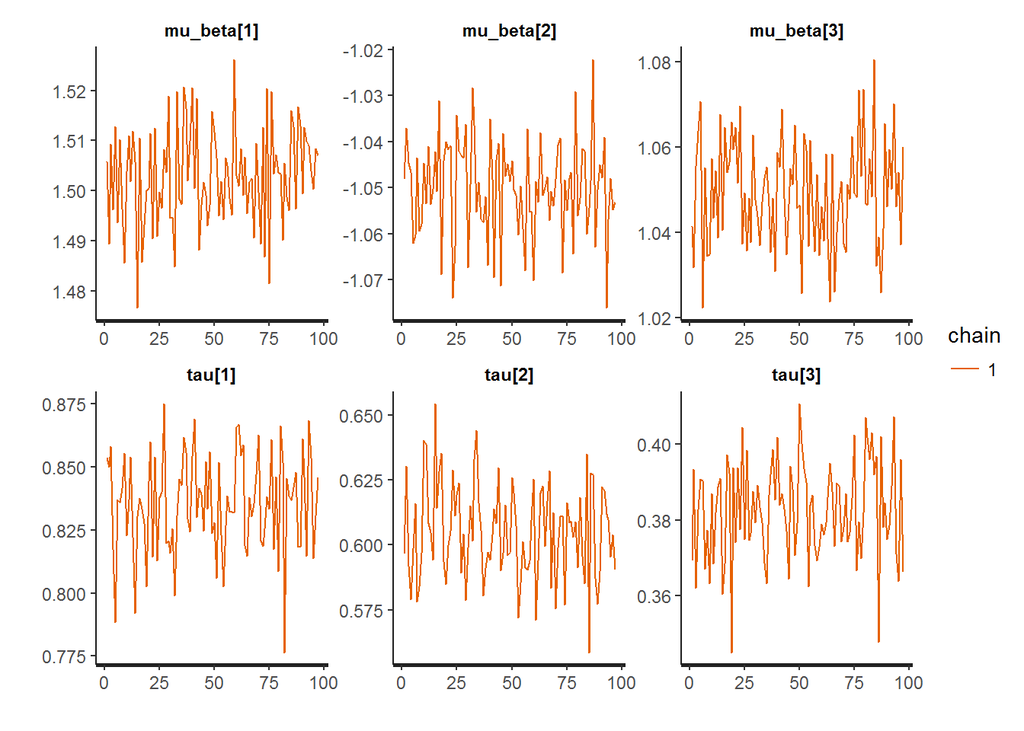

```r
traceplot(hievbfit,pars=c("mu_beta","tau"))
```

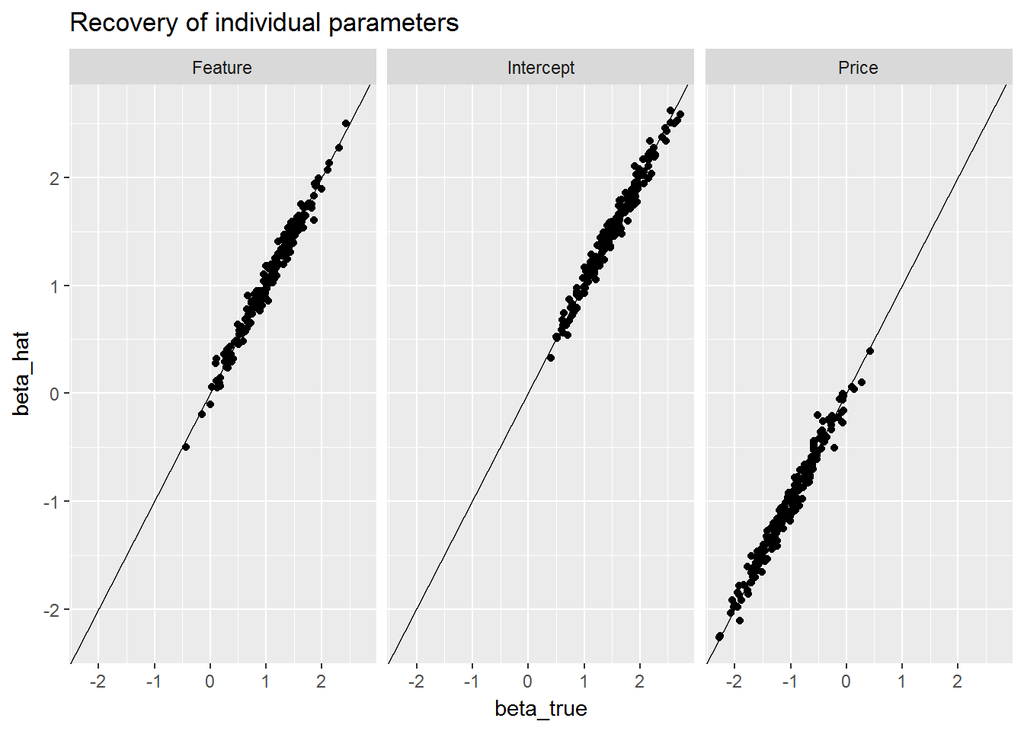

```r
beta_hat <- matrix(get_posterior_mean(hierfit,pars="beta"),nrow = I,ncol = P,byrow = TRUE)
ggplot(data = data.frame(beta_true=c(beta),
                         beta_hat=c(beta_hat),
                         param=rep(c("Intercept","Price","Feature"),each = I)),
       aes(x=beta_true,y=beta_hat))+geom_point()+facet_grid(.~param)+geom_abline(intercept = 0,slope = 1) + labs(title = "Recovery of individual parameters")
```